# Bloque 1

Septiembre, 2017

## Temas

- Problemas en el diseño experimental de reservas
- Evaluación Antes-Después
- Evaluación Dentro-Fuera
- Evaluación Antes-Después-Dentro-Fuera
- Ejemplos

## Experimentos aleatorios controlados

- Las RM no se asignan aleatoriamente
- Los candidatos tienen (o tenían) características clave:
  - Conectividad
  - Productividad
  - Heterogeneidad de hábitat
- Hay que ser cuidadosos al evaluar reservas, pues podemos malinformar
- Los siguientes ejemplos **no** son malos estudios, nuestra interpretación es incorrecta

## Evaluación Antes-Después

**Características**

- Se evalúan cambios en los indicadores a través del tiempo
- No hay un sitio control

## Evaluación Antes-Después

**Ejemplo:** Wantiez, Thollot, and Kulbicki (1997)

- RMs en Nueva Celadonia
- Comparación entre 1990 y 1994
- Comparan riqueza, biomasa y densidades

## Evaluación Antes-Después

**Resultados**

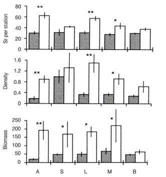

- *"Marine reserve protection* **resulted** *in an increase in the relative abundance and species richness of large edible species within the assemblages"*
- *"Species richness, density, and biomass of fish on the protected reefs increased respectively by 67%, 160% and 246%."*… **"This increase was statistically significant."**

## Evaluación Antes-Después

**Reflexiones**

- **Sí hay un cambio** pero…
  - El análisis rechaza \(H_0: \mu_1-\mu_2 = 0\)
  - No hay **evidencia** de que sea por efecto de la reserva
  - Tendemos a asumir que hay una relación causal
- No toma en cuenta otras intervenciones (*e.g.* mejor manejo pesquero en general)
- El ambiente entero se pudo haber hecho más productivo (Szuwalski et al. 2017)
- Interpretación errónea: Implementar una reserva incrementa la biomasa en 246% en sólo 4 años
- Lo correcto: Entre 1990 y 1994, hubo un incremento de biomasa del 246%

## Evaluación Dentro-Fuera

**Características**

- Se evalúan diferencias entre dentro y fuera
- No hay componente temporal (suele ser por falta de línea base)

## Evaluación Dentro-Fuera

**Ejemplo:** Friedlander et al. (2017)

- Red de AMPs de Palau (se enfocan en las RM)
- Implementadas en 2003 (pero larga historia de manejo comunitario)
- Usan biomasa de peces para medir el efecto
- Controles son: *"similar adjacent unprotected habitats"*

## Evaluación Dentro-Fuera

**Resultados**

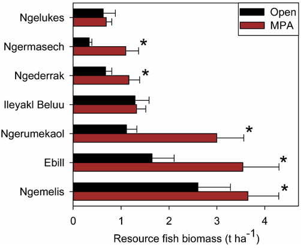

- *"Our results showed that no-take MPAs had, on average, nearly twice the biomass of resource fishes (i.e. those important commercially, culturally, or for subsistence) compared to nearby unprotected areas."*
- También mencionan que estos cambios no eran evidentes en especies no pescadas.

## Evaluación Dentro-Fuera

**Reflexiones**

- No es un experimento controlado (las reservas se pusieron ahí por una razón)
  - ¿Zonas nauralmente productivas?
  - ¿Zonas con alto reclutamiento / conectividad?
- Existen diferencias entre RM y Control
  - Se rechaza \(H_0: \mu_1-\mu_2 = 0\)
  - ¿Reserva subió o control bajó?
- En su defensa:
  - Las especies no pescadas no responden al tratamiento
  - Mejor aproximación que antes-después, pero aún no podemos inferir causalidad

## Evaluación Antes-Después-Control-Impacto

**Características**

- Demandante en datos:
  - Datos de línea base
  - Datos para reserva y control
- Asumimos que:
  - Reserva y control tenían la misma probabilidad de haber sido reserva
  - Tendencias paralelas previo a implementación
- Nos permite estimar el efecto neto de la reserva

## Evaluación Antes-Después-Control-Impacto

**Ejemplo:** Moland et al. (2013)

- RM en Noruega
- Diseñadas para bacalao y langosta
- Diseño muestreal BACI
- Usan modelo de diferencia en diferencias
- Muestreo "pesquero", utilizan CPUE como indicador

## Evaluación Antes-Después-Control-Impacto

**Resultados**

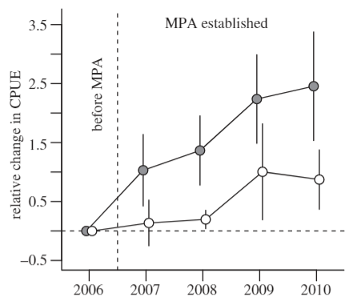

- "*The effect of [time] depended on treatment and that population development was different between treatments*"
- "*By 2010, the mean relative CPUE had increased by 245 percent in MPAs, whereas mean relative CPUE in control areas had increased by 87 percent*"

## Evaluación Antes-Después-Control-Impacto

**Reflexiones**

- Diferencia entre incremento en reserva (245%) e incremento en control (87%) nos da el efecto **real** de la reserva:
- \(\Delta_r - \Delta_c = Efecto\)
- \(245 - 87 = 158\)

## Ejemplo de las tres metodologías

## Ejemplo

Supongamos:

| Zona | Antes | Después |
| --- | --- | --- |
| Control | 2 | 4 |
| Reserva | 4 | 9 |

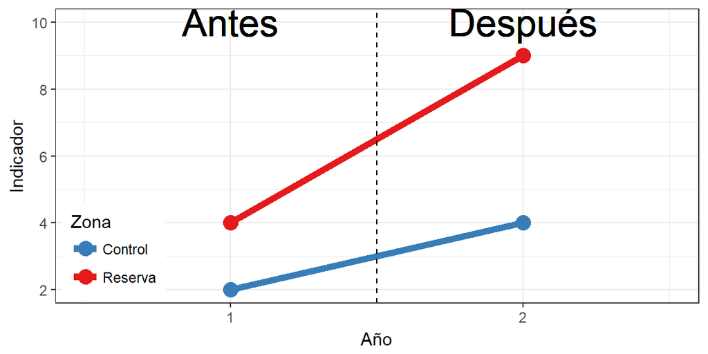

## Ejemplo

**Antes-Después**

| Zona | Antes | Después | Cambio |
| --- | --- | --- | --- |
| Control | 2 | 4 | NA |
| Reserva | 4 | 9 | 5 |

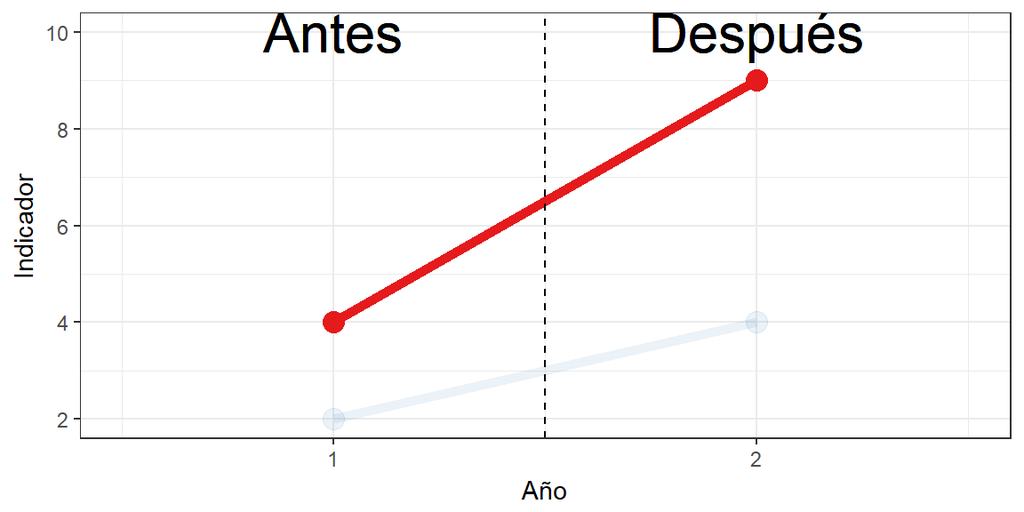

## Ejemplo

**Dentro-Fuera**

| Zona | Antes | Después |
| --- | --- | --- |
| Control | 2 | 4 |
| Reserva | 4 | 9 |
| Cambio | NA | 5 |

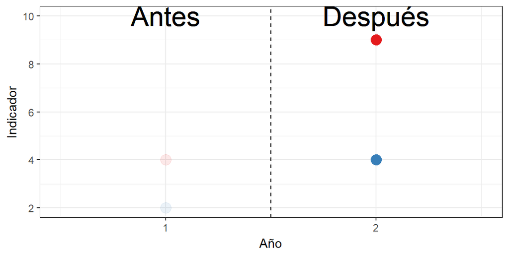

## Ejemplo

**Antes-Después-Control-Impacto**

| Zona | Antes | Después | Cambio |
| --- | --- | --- | --- |
| Control | 2 | 4 | 2 |
| Reserva | 4 | 9 | 5 |
| Cambio | 2 | 5 | 3 |

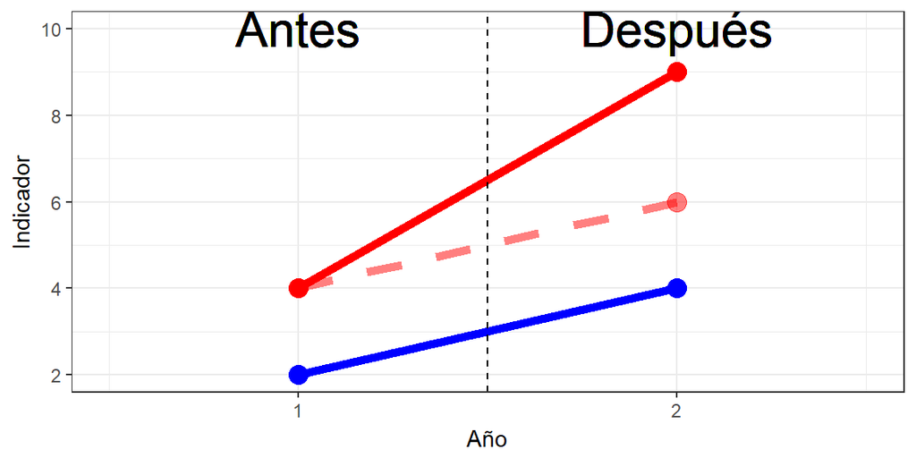

## Referencias

Friedlander, Alan M, Yimnang Golbuu, Enric Ballesteros, Jennifer E Caselle, Marine Gouezo, Dawnette Olsudong, and Enric Sala. 2017. “Size, Age, and Habitat Determine Effectiveness of Palau’s Marine Protected Areas.” *PLoS ONE* 12 (3): e0174787. doi:10.1371/journal.pone.0174787.

Moland, Even, Esben Moland Olsen, Halvor Knutsen, Pauline Garrigou, Sigurd Heiberg Espeland, Alf Ring Kleiven, Carl André, and Jan Atle Knutsen. 2013. “Lobster and Cod Benefit from Small-Scale Northern Marine Protected Areas: Inference from an Empirical Before-After Control-Impact Study.” *Proc Biol Sci* 280 (1754): 20122679. doi:10.1098/rspb.2012.2679.

Szuwalski, Cody S, Matthew G Burgess, Christopher Costello, and Steven D Gaines. 2017. “High Fishery Catches Through Trophic Cascades in China.” *Proc Natl Acad Sci U S A* 114 (4): 717–21. doi:10.1073/pnas.1612722114.

Wantiez, L., P. Thollot, and M. Kulbicki. 1997. “Effects of Marine Reserves on Coral Reef Fish Communities from Five Islands in New Caledonia.” *Coral Reefs* 16 (4): 215–24. doi:10.1007/s003380050077.

## Bloque 2